# House Price Prediction using Machine Learning

### The Dataset

The dataset has 13 features.

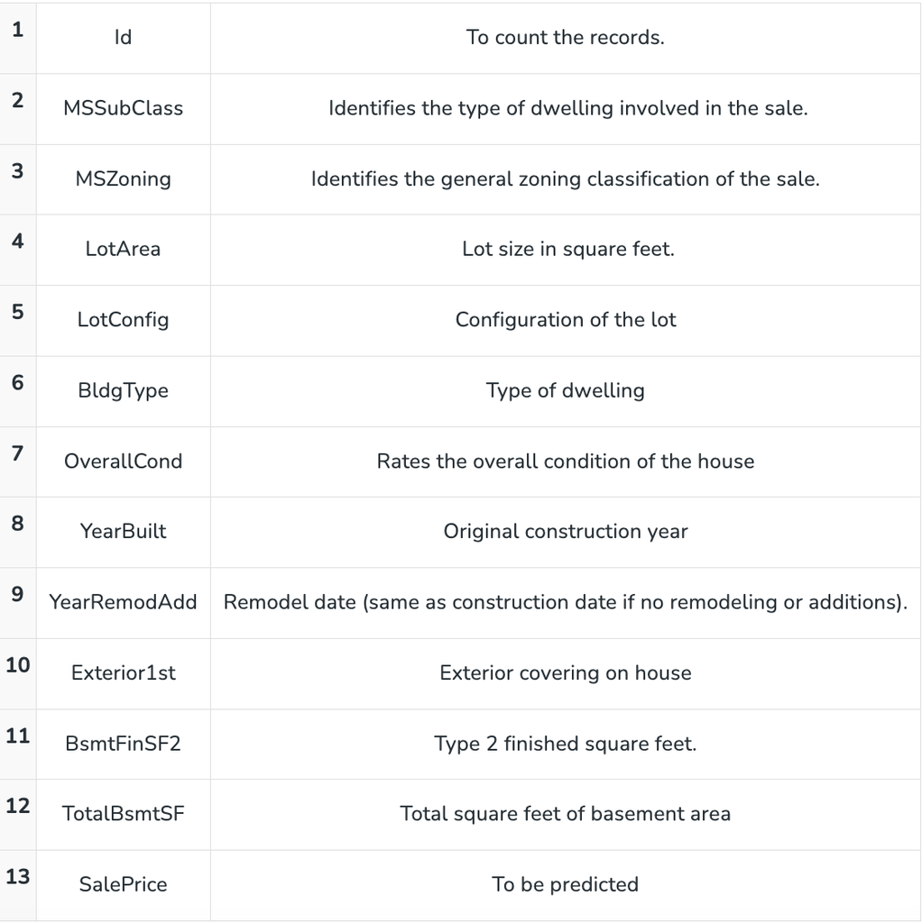

### Importing Libraries and Dataset

```python
import pandas as pd
import matplotlib.pyplot as plt
import seaborn as sns
```

```python
dataset = pd.read_csv("house_price.csv")
```

```python
dataset.head(5)
```

|  | Id | MSSubClass | MSZoning | LotArea | LotConfig | BldgType | OverallCond | YearBuilt | YearRemodAdd | Exterior1st | BsmtFinSF2 | TotalBsmtSF | SalePrice |
| --- | --- | --- | --- | --- | --- | --- | --- | --- | --- | --- | --- | --- | --- |
| 0 | 0 | 60 | RL | 8450 | Inside | 1Fam | 5 | 2003 | 2003 | VinylSd | 0.0 | 856.0 | 208500.0 |
| 1 | 1 | 20 | RL | 9600 | FR2 | 1Fam | 8 | 1976 | 1976 | MetalSd | 0.0 | 1262.0 | 181500.0 |
| 2 | 2 | 60 | RL | 11250 | Inside | 1Fam | 5 | 2001 | 2002 | VinylSd | 0.0 | 920.0 | 223500.0 |
| 3 | 3 | 70 | RL | 9550 | Corner | 1Fam | 5 | 1915 | 1970 | Wd Sdng | 0.0 | 756.0 | 140000.0 |
| 4 | 4 | 60 | RL | 14260 | FR2 | 1Fam | 5 | 2000 | 2000 | VinylSd | 0.0 | 1145.0 | 250000.0 |

```python
dataset.info()
```

```
<class 'pandas.core.frame.DataFrame'>
RangeIndex: 2919 entries, 0 to 2918
Data columns (total 13 columns):
 #   Column        Non-Null Count  Dtype
---  ------        --------------  -----
 0   Id            2919 non-null   int64
 1   MSSubClass    2919 non-null   int64
 2   MSZoning      2915 non-null   object
 3   LotArea       2919 non-null   int64
 4   LotConfig     2919 non-null   object
 5   BldgType      2919 non-null   object
 6   OverallCond   2919 non-null   int64
 7   YearBuilt     2919 non-null   int64
 8   YearRemodAdd  2919 non-null   int64
 9   Exterior1st   2918 non-null   object
 10  BsmtFinSF2    2918 non-null   float64
 11  TotalBsmtSF   2918 non-null   float64
 12  SalePrice     1460 non-null   float64
dtypes: float64(3), int64(6), object(4)
memory usage: 296.6+ KB
```

```python
dataset.shape
```

```
(2919, 13)
```

### Data Preprocessing

Now, we categorize the features depending on their datatype (int, float, object) and then calculate the number of them.

```python
obj = (dataset.dtypes == 'object')
object_cols = list(obj[obj].index)
print("Categorical variables:",len(object_cols))

int_ = (dataset.dtypes == 'int')
num_cols = list(int_[int_].index)
print("Integer variables:",len(num_cols))

fl = (dataset.dtypes == 'float')
fl_cols = list(fl[fl].index)
print("Float variables:",len(fl_cols))
```

```
Categorical variables: 4
Integer variables: 6
Float variables: 3
```

### Exploratory Data Analysis

1. To know relation between different features lets draw **Heatmap**.

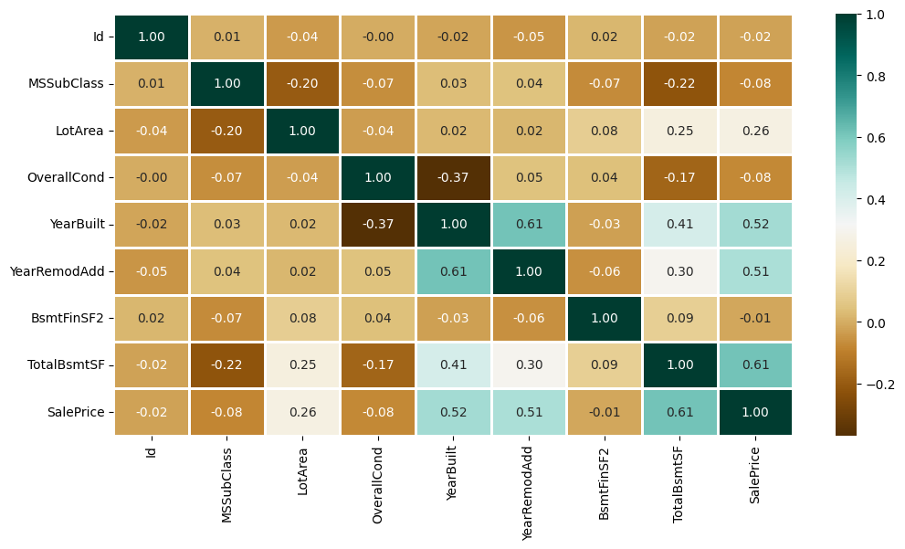

```python
plt.figure(figsize=(12, 6))
sns.heatmap(dataset.corr(),
            cmap = 'BrBG',
            fmt = '.2f',
            linewidths = 2,
            annot = True)
```

2. To analyze the different categorical features. Let’s draw the **barplot**.

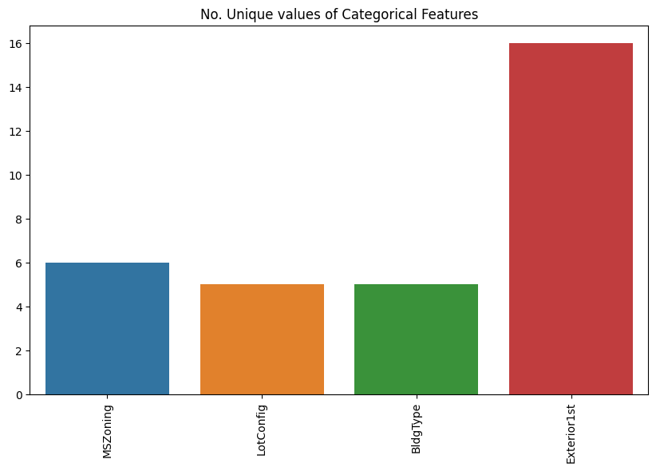

```python
# find the unique values
unique_values = []
for col in object_cols:
  unique_values.append(dataset[col].unique().size)

plt.figure(figsize=(10,6))
plt.title('No. Unique values of Categorical Features')
plt.xticks(rotation=90)
sns.barplot(x=object_cols,y=unique_values)
```

The plot shows that Exterior1st has around 16 unique categories and other features have around 6 unique categories. To findout the actual count of each category we can plot the bargraph of each four features separately.

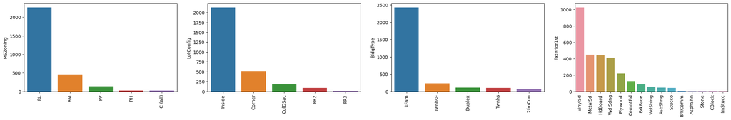

```python
plt.figure(figsize=(28, 46))
plt.title('Categorical Features: Distribution')
plt.xticks(rotation=90)
index = 1

for col in object_cols:
    y = dataset[col].value_counts()
    plt.subplot(11, 4, index)
    plt.xticks(rotation=90)
    sns.barplot(x=list(y.index), y=y)
    index += 1
```

### Data Cleaning

Data Cleaning is the way to improvise the data or remove incorrect, corrupted or irrelevant data.

- As in our dataset, there are some columns that are not important and irrelevant for the model training. So, we can drop that column before training. There are 2 approaches to dealing with empty/null values
- We can easily delete the column/row (if the feature or record is not much important). Filling the empty slots with mean/mode/0/NA/etc. (depending on the dataset requirement). As Id Column will not be participating in any prediction. So we can Drop it.
1. As Id Column will not be participating in any prediction. So we can Drop it.

```python
dataset.drop(['Id'],
			axis=1,
			inplace=True)
```

2. Replacing SalePrice empty values with their mean values to make the data distribution symmetric.

```python
dataset['SalePrice'] = dataset['SalePrice'].fillna(dataset['SalePrice'].mean())
```

3. Drop records with null values (as the empty records are very less).

```python
new_dataset = dataset.dropna()
```

4. Checking features which have null values in the new dataframe (if there are still any).

```python
new_dataset.isnull().sum()
```

```
MSSubClass      0
MSZoning        0
LotArea         0
LotConfig       0
BldgType        0
OverallCond     0
YearBuilt       0
YearRemodAdd    0
Exterior1st     0
BsmtFinSF2      0
TotalBsmtSF     0
SalePrice       0
dtype: int64
```

### OneHotEncoder – For Label categorical features

One hot Encoding is the best way to convert categorical data into binary vectors. This maps the values to integer values. By using OneHotEncoder, we can easily convert object data into int. So for that, firstly we have to collect all the features which have the object datatype. To do so, we will make a loop.

```python
from sklearn.preprocessing import OneHotEncoder

s = (new_dataset.dtypes == 'object')
object_cols = list(s[s].index)
print("Categorical variables:")
print(object_cols)
print('No. of. categorical features: ',
	len(object_cols))
```

```
Categorical variables:
['MSZoning', 'LotConfig', 'BldgType', 'Exterior1st']
No. of. categorical features:  4
```

Then once we have a list of all the features. We can apply OneHotEncoding to the whole list.

```python
OH_encoder = OneHotEncoder(sparse_output=False)
OH_cols = pd.DataFrame(OH_encoder.fit_transform(new_dataset[object_cols]))
OH_cols.index = new_dataset.index
OH_cols.columns = OH_encoder.get_feature_names_out()
df_final = new_dataset.drop(object_cols, axis=1)
df_final = pd.concat([df_final, OH_cols], axis=1)
```

```python
df_final
```

|  | MSSubClass | LotArea | OverallCond | YearBuilt | YearRemodAdd | BsmtFinSF2 | TotalBsmtSF | SalePrice | MSZoning_C (all) | MSZoning_FV | ... | Exterior1st_CemntBd | Exterior1st_HdBoard | Exterior1st_ImStucc | Exterior1st_MetalSd | Exterior1st_Plywood | Exterior1st_Stone | Exterior1st_Stucco | Exterior1st_VinylSd | Exterior1st_Wd Sdng | Exterior1st_WdShing |
| --- | --- | --- | --- | --- | --- | --- | --- | --- | --- | --- | --- | --- | --- | --- | --- | --- | --- | --- | --- | --- | --- |
| 0 | 60 | 8450 | 5 | 2003 | 2003 | 0.0 | 856.0 | 208500.00000 | 0.0 | 0.0 | ... | 0.0 | 0.0 | 0.0 | 0.0 | 0.0 | 0.0 | 0.0 | 1.0 | 0.0 | 0.0 |
| 1 | 20 | 9600 | 8 | 1976 | 1976 | 0.0 | 1262.0 | 181500.00000 | 0.0 | 0.0 | ... | 0.0 | 0.0 | 0.0 | 1.0 | 0.0 | 0.0 | 0.0 | 0.0 | 0.0 | 0.0 |
| 2 | 60 | 11250 | 5 | 2001 | 2002 | 0.0 | 920.0 | 223500.00000 | 0.0 | 0.0 | ... | 0.0 | 0.0 | 0.0 | 0.0 | 0.0 | 0.0 | 0.0 | 1.0 | 0.0 | 0.0 |
| 3 | 70 | 9550 | 5 | 1915 | 1970 | 0.0 | 756.0 | 140000.00000 | 0.0 | 0.0 | ... | 0.0 | 0.0 | 0.0 | 0.0 | 0.0 | 0.0 | 0.0 | 0.0 | 1.0 | 0.0 |
| 4 | 60 | 14260 | 5 | 2000 | 2000 | 0.0 | 1145.0 | 250000.00000 | 0.0 | 0.0 | ... | 0.0 | 0.0 | 0.0 | 0.0 | 0.0 | 0.0 | 0.0 | 1.0 | 0.0 | 0.0 |
| ... | ... | ... | ... | ... | ... | ... | ... | ... | ... | ... | ... | ... | ... | ... | ... | ... | ... | ... | ... | ... | ... |
| 2914 | 160 | 1936 | 7 | 1970 | 1970 | 0.0 | 546.0 | 180921.19589 | 0.0 | 0.0 | ... | 1.0 | 0.0 | 0.0 | 0.0 | 0.0 | 0.0 | 0.0 | 0.0 | 0.0 | 0.0 |
| 2915 | 160 | 1894 | 5 | 1970 | 1970 | 0.0 | 546.0 | 180921.19589 | 0.0 | 0.0 | ... | 1.0 | 0.0 | 0.0 | 0.0 | 0.0 | 0.0 | 0.0 | 0.0 | 0.0 | 0.0 |
| 2916 | 20 | 20000 | 7 | 1960 | 1996 | 0.0 | 1224.0 | 180921.19589 | 0.0 | 0.0 | ... | 0.0 | 0.0 | 0.0 | 0.0 | 0.0 | 0.0 | 0.0 | 1.0 | 0.0 | 0.0 |
| 2917 | 85 | 10441 | 5 | 1992 | 1992 | 0.0 | 912.0 | 180921.19589 | 0.0 | 0.0 | ... | 0.0 | 1.0 | 0.0 | 0.0 | 0.0 | 0.0 | 0.0 | 0.0 | 0.0 | 0.0 |
| 2918 | 60 | 9627 | 5 | 1993 | 1994 | 0.0 | 996.0 | 180921.19589 | 0.0 | 0.0 | ... | 0.0 | 1.0 | 0.0 | 0.0 | 0.0 | 0.0 | 0.0 | 0.0 | 0.0 | 0.0 |

2913 rows × 38 columns

### Splitting Dataset into Training and Testing

X and Y splitting (i.e. Y is the SalePrice column and the rest of the other columns are X)

```python
from sklearn.metrics import mean_absolute_error
from sklearn.model_selection import train_test_split

X = df_final.drop(['SalePrice'], axis=1)
Y = df_final['SalePrice']

# Split the training set into
# training and validation set
X_train, X_valid, Y_train, Y_valid = train_test_split(
	X, Y, train_size=0.8, test_size=0.2, random_state=0)
```

### Model and Accuracy

As we have to train the model to determine the continuous values, so we will be using these regression models.

- SVM-Support Vector Machine
- Random Forest Regressor
- Linear Regressor

[figure not shown]

```python
error_list = []
```

### SVM – Support vector Machine

SVM can be used for both regression and classification model.

```python
from sklearn import svm
from sklearn.svm import SVC
from sklearn.metrics import mean_absolute_percentage_error

model_SVR = svm.SVR()
model_SVR.fit(X_train,Y_train)
Y_pred = model_SVR.predict(X_valid)

error_list.append(mean_absolute_percentage_error(Y_valid, Y_pred)*1000)
```

### Random Forest Regression

Random Forest is an ensemble technique that uses multiple of decision trees and can be used for both regression and classification task

```python
from sklearn.ensemble import RandomForestRegressor

model_RFR = RandomForestRegressor(n_estimators=10)
model_RFR.fit(X_train, Y_train)
Y_pred = model_RFR.predict(X_valid)

error_list.append(mean_absolute_percentage_error(Y_valid, Y_pred)*1000)
```

### Linear Regression

Linear Regression predicts the final output-dependent value based on the given independent features. Like, here we have to predict SalePrice depending on features like MSSubClass, YearBuilt, BldgType, Exterior1st etc

```python
from sklearn.linear_model import LinearRegression

model_LR = LinearRegression()
model_LR.fit(X_train, Y_train)
Y_pred = model_LR.predict(X_valid)

error_list.append(mean_absolute_percentage_error(Y_valid, Y_pred)*1000)
```

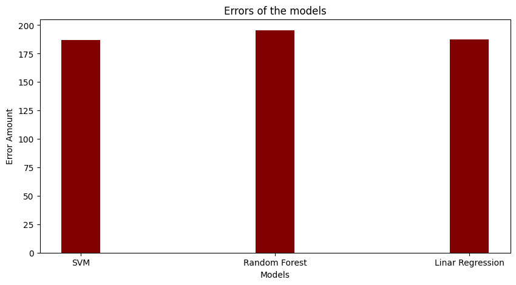

```python
model_list = ['SVM','Random Forest','Linar Regression']

fig = plt.figure(figsize = (10, 5))

# creating the bar plot
plt.bar(model_list, error_list, color ='maroon',
        width = 0.2)

plt.xlabel("Models")
plt.ylabel("Error Amount")
plt.title("Errors of the models")
plt.show()
```

### Predictions

```python
import warnings

# Suppress all warnings
warnings.filterwarnings("ignore")
```

```python
import random
import numpy as np

Xnew = [random.uniform(0.0, 1.0) for _ in range(37)]
Xnew = np.array(Xnew).reshape(1, 37)

# make a prediction
ynew = model_SVR.predict(Xnew)

# show the inputs and predicted outputs
print("X=%s, \n\nPredicted=%s" % (Xnew[0], ynew[0]))
```

```
X=[0.81371278 0.11073266 0.7366059  0.95325405 0.75131518 0.69880804
 0.70578338 0.65889493 0.72854848 0.11956016 0.13289843 0.16977503
 0.91564498 0.87357071 0.68957066 0.15559605 0.85567241 0.38471179
 0.24137916 0.06091091 0.0481377  0.00315177 0.80409491 0.04213334
 0.17809308 0.0289522  0.58360517 0.34527942 0.00253616 0.84441924
 0.56807134 0.57848109 0.53259882 0.68249716 0.64925207 0.19192104
 0.42225821],

Predicted=180920.96280298693
```